# Graphics

## Graphics

- base: old system
- lattice: creating function to plot
- ggplot2

## Base

- example of a base graphics

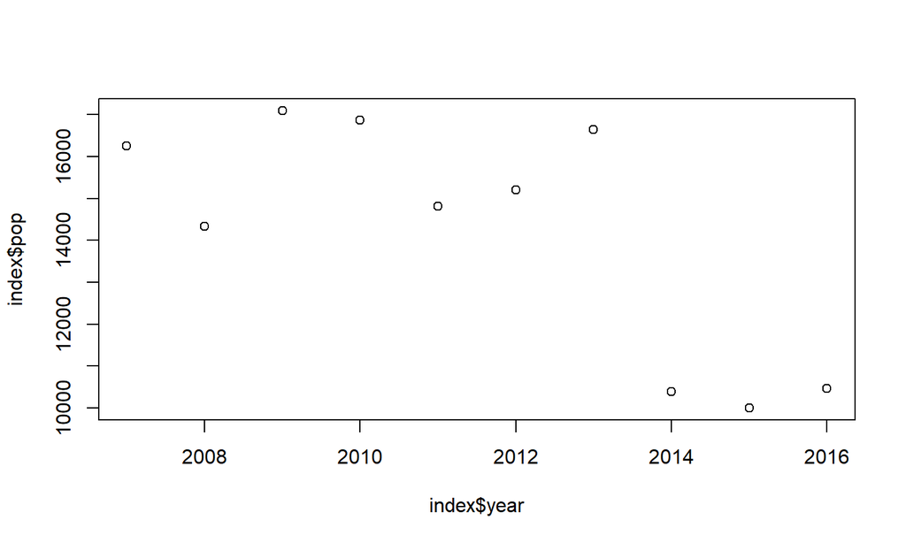

```r
index<-data.frame(year=2007:2016, pop=sample(10000:20000, size=10))

plot(index$year,index$pop)
```

## Base - lines

- type lines

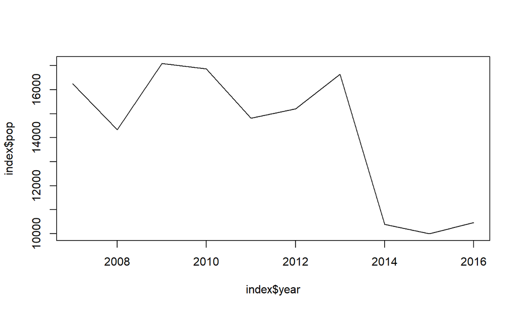

```r
#lines
plot(index$year,index$pop, type="l")
```

## Base - histrogram

- type histogram

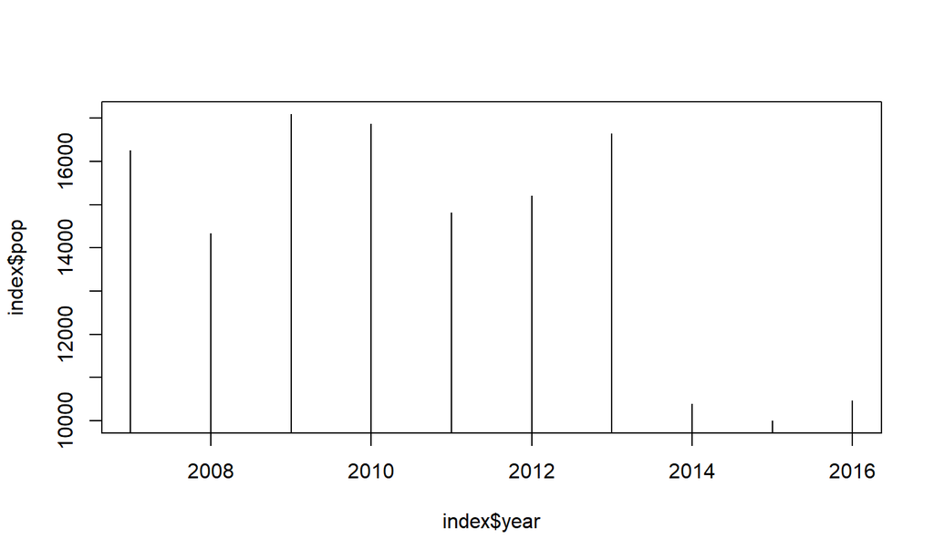

```r
plot(index$year,index$pop, type="h")
```

## Base - title and axis labels

- adding title and axis labels

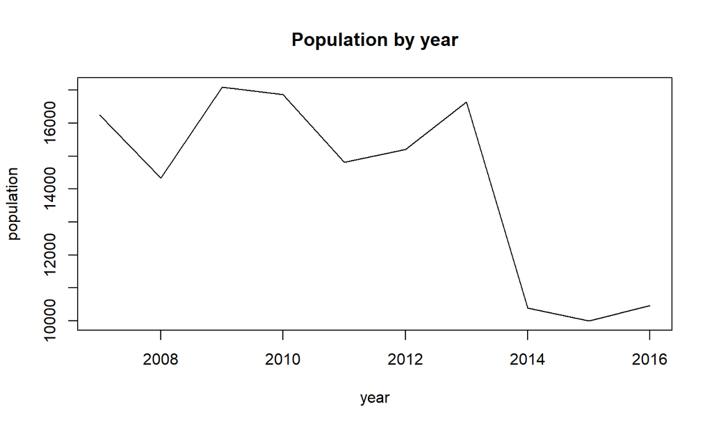

```r
plot(index$year,index$pop, type="l", main="Population by year",
     xlab="year",ylab="population")
```

## Lab

- use mtcars dataset and create a line plot where cyl must be on x axis and mean mpg on y axis

## Lattice - creating a function

- pop~year or mean mpg~cyl

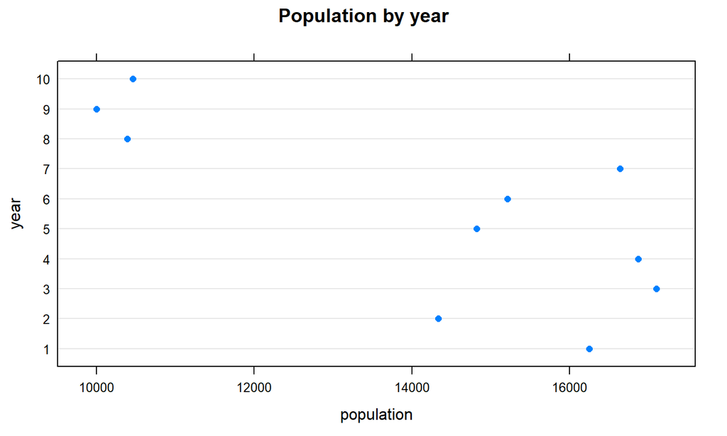

```r
lattice::dotplot(year~pop,data=index,main="Population by year",
        ylab="year",xlab="population")
```

## Lattice - problem with y-values

- we must change year values to factors

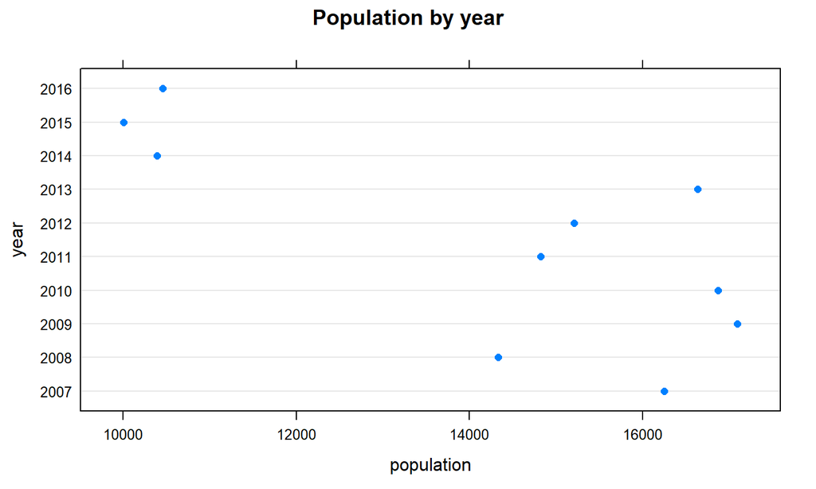

```r
index$year<-as.factor(index$year)
lattice::dotplot(year~pop,data=index,main="Population by year",
        ylab="year",xlab="population")
```

## Lattice - histrogram

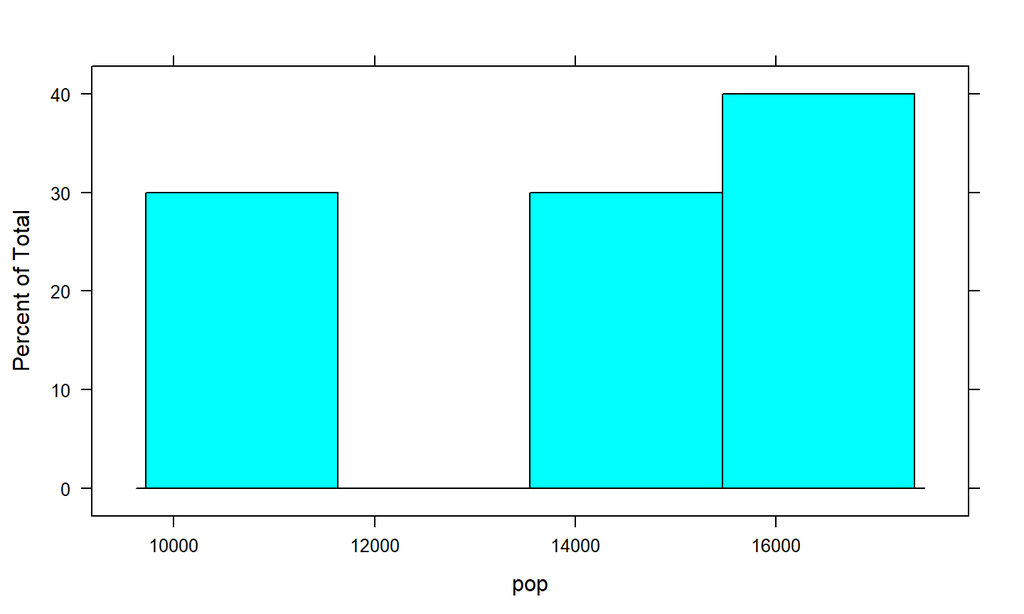

```r
histogram(year~pop,data=index)
```

##Lattice - more complex formula

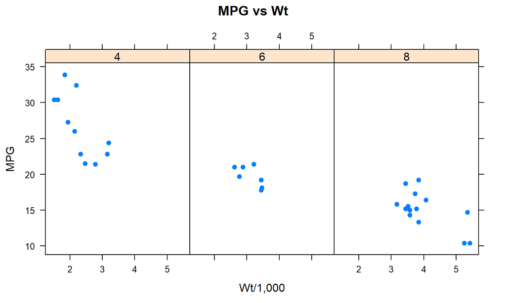

```r
xyplot(mpg~wt | factor(cyl), data=mtcars, pch=19,
                main="MPG vs Wt", xlab="Wt/1,000",  ylab="MPG")
```

## Lab

- use mtcars dataset and create a barchart of mean mpg for number of gears per cyl

## ggplot2

- Foundation for many graphics applications:
  - ggplot2
  - Tableau
  - Vega-Lite

[figure not shown]

## ggplot2 - The idea

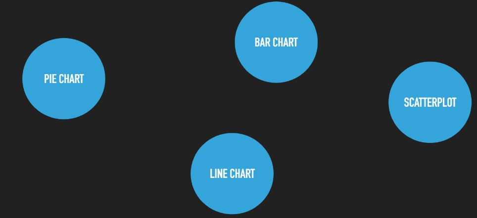

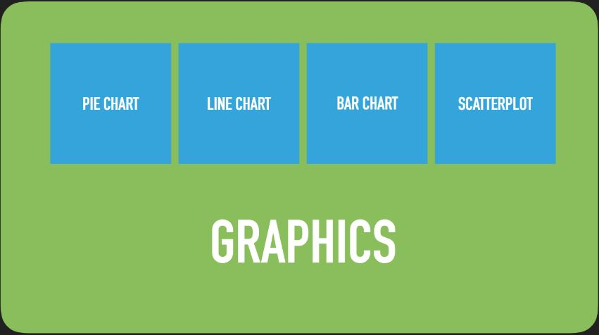

## ggplot2

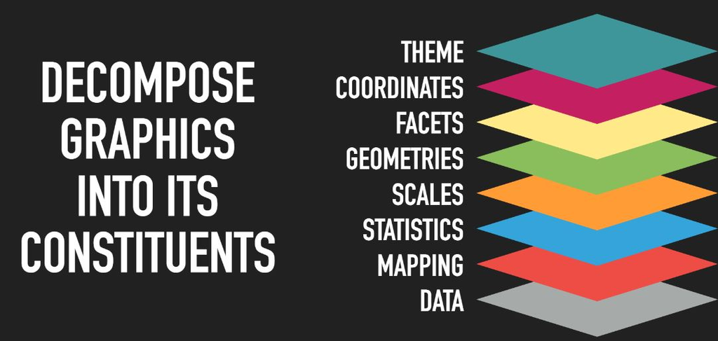

## ggplot2

- data: data.frame
- aes: mapping data to properties; color, format and size
- stats: transforms input variables to display values
- scales: translate between variable ranges and properties ranges - categories -> colours; numbers -> positions
- geoms: geometric objects (points, lines, …)
- facets: forms a matrix of panels defined by row and column faceting variable
- coordinates: defines the phiysical mapping of the aesthetics to the paper
- themes: every part of the graphic that is not linked to the data

## ggplot2 - basic object

- which data to plot
- which columns to use for x and y
- how to draw the plot
- “+” is used to combine the ggplot2 elements

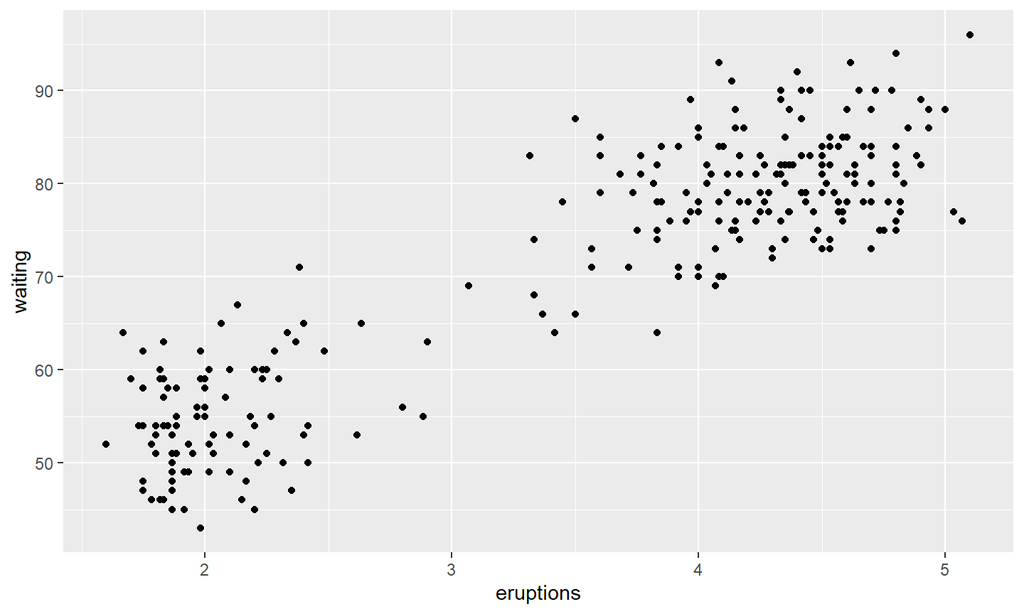

```r
ggplot(data=faithful,
       mapping=aes(x=eruptions,
                   y=waiting))+
  geom_point()
```

## ggplot2 - different syntax

```
ggplot(data=faithful)+
  geom_point(mapping=aes(x=eruptions,
                   y=waiting))
```

```
ggplot()+
  geom_point(data=faithful,mapping=aes(x=eruptions,
                   y=waiting))
```

## ggplot2 - adding colour

- we can create subgroups in ggplot2 with colour parameter

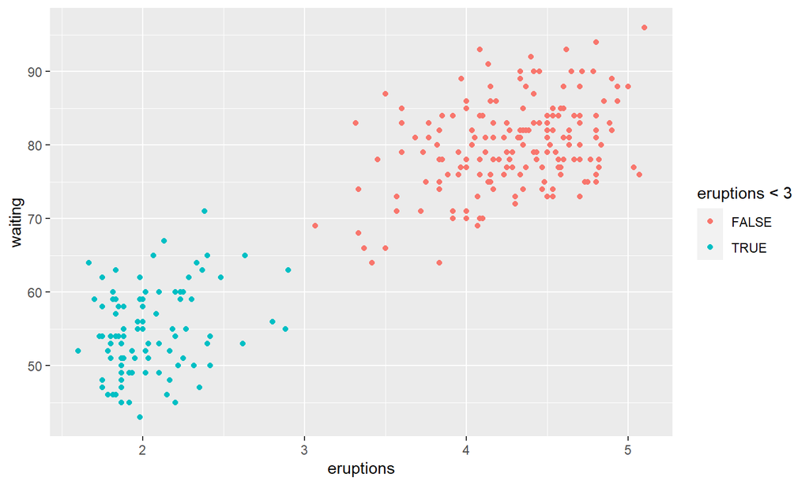

```r
ggplot(data=faithful)+
  geom_point(mapping=aes(x=eruptions,y=waiting,
                         colour=eruptions<3))
```

## ggplot2 - different geometry

- some geoms only need a single mapping and will calculate the rest for you

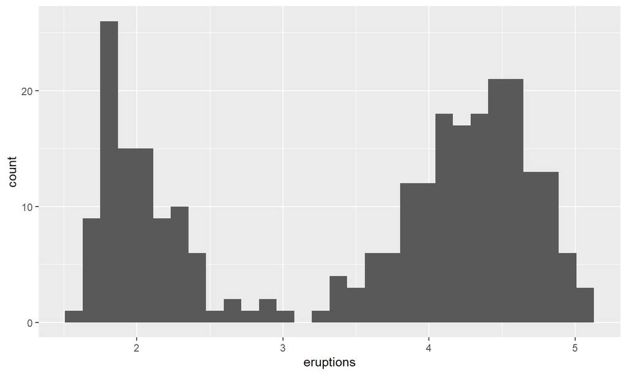

```r
ggplot(data=faithful)+
  geom_histogram(mapping=aes(x=eruptions))
```

## ggplot2 - many layers

- layers are stacked int the order of code appearance

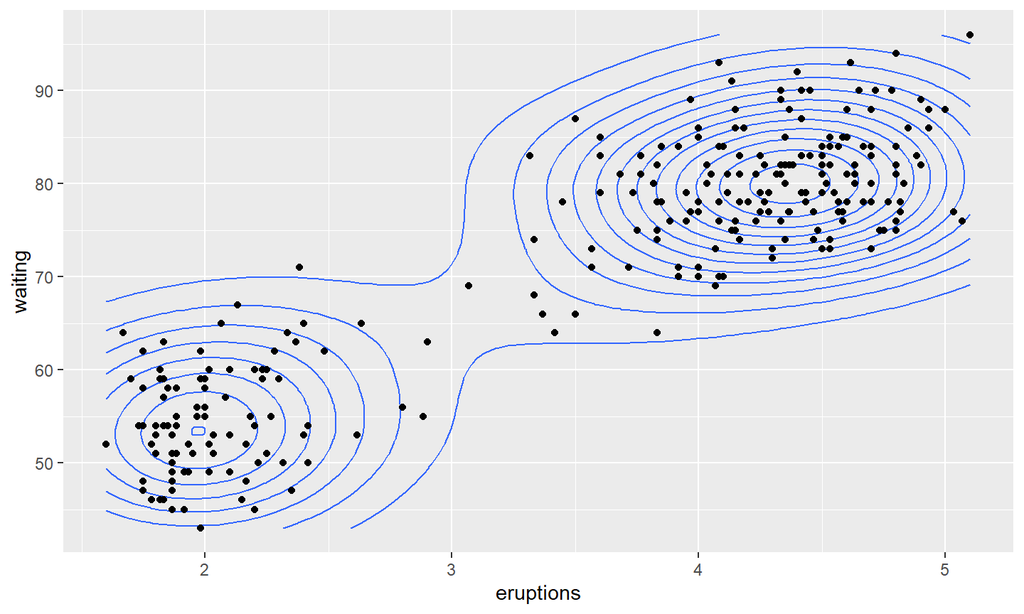

```r
ggplot(data=faithful,
       mapping=aes(x=eruptions,
                   y=waiting))+
  geom_density_2d()+
  geom_point()
```

## Lab

- open ggplot2.txt. Solve excercises 1-4!

## ggplot2 - statistics - 1

- geom_bar uses stat_count() by default

```
ggplot(mpg) +
  geom_bar(aes(x = class))
```

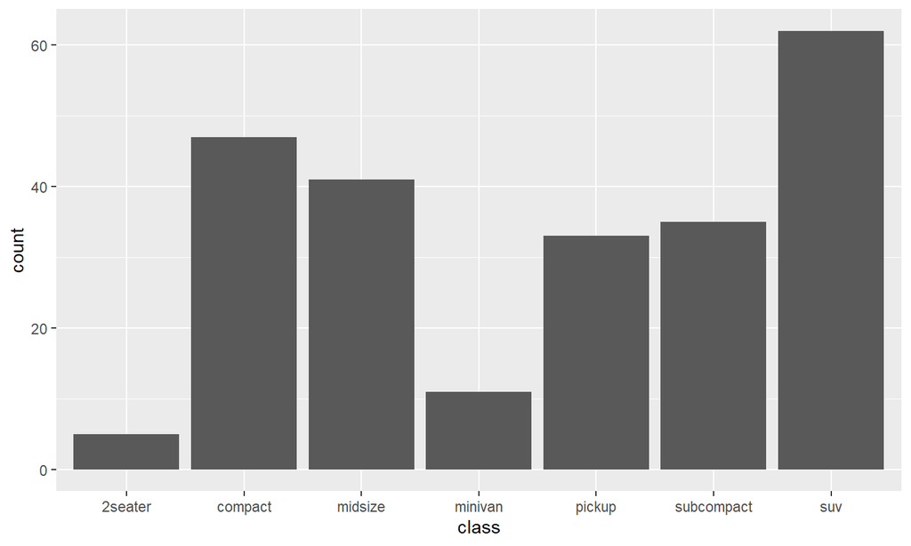

## ggplot2 - statistics - 2

- you can pre-calculate
- and use stat = ‘identity’

```
mpg_counted <- mpg %>%
  count(class, name = 'count')

ggplot(mpg_counted) +
  geom_bar(aes(x = class,
              y = count),
        stat = 'identity')
```

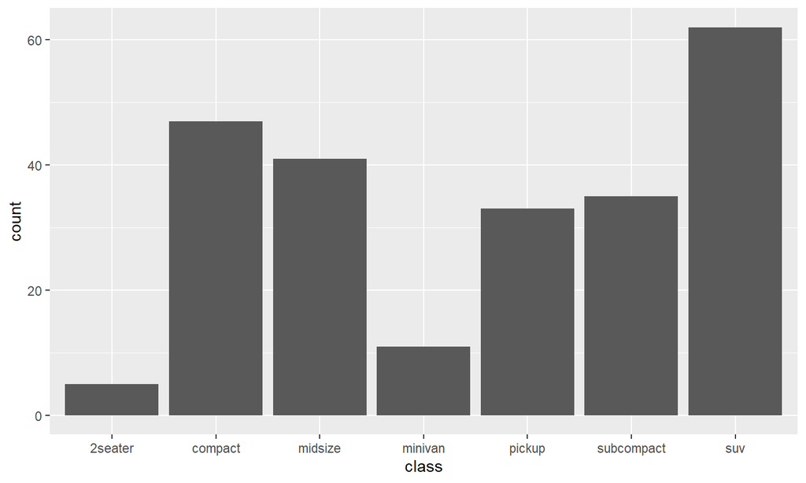

## ggplot2 - statistics - 3

- using after_stat (ggplot2 ver3.3.0)
- modifying mapping from stats

```
ggplot(mpg) +
  geom_bar(aes(x = class,
  y = after_stat(100 * count /
                  sum(count))))
```

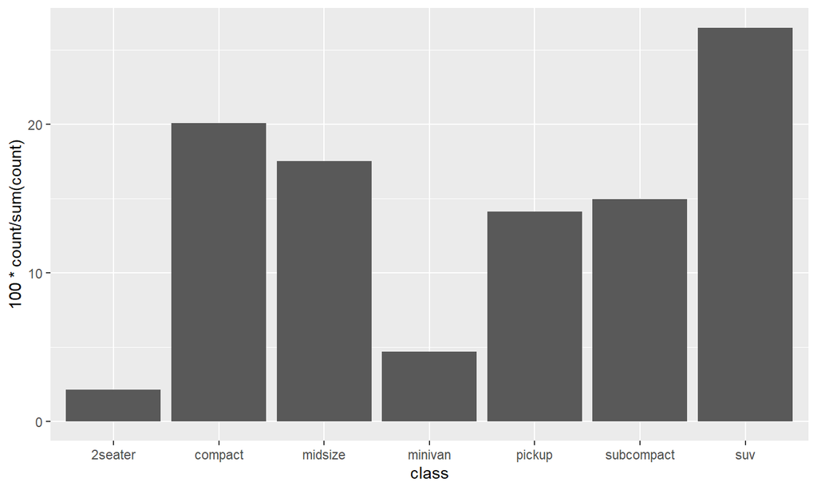

Values calculated by the stat is available with the `after_stat()` function inside `aes()`

## Lab

- open ggplot2 and solve the 5th excercise
- additional hint:…+ stat_summary(aes(x = class, y = hwy),fun=?, geom = “point”, color=?)

## ggplot2 - scales - 1

```
ggplot(mpg) +
  geom_point(
  aes(x = displ,
      y = hwy,
  colour = class))
```

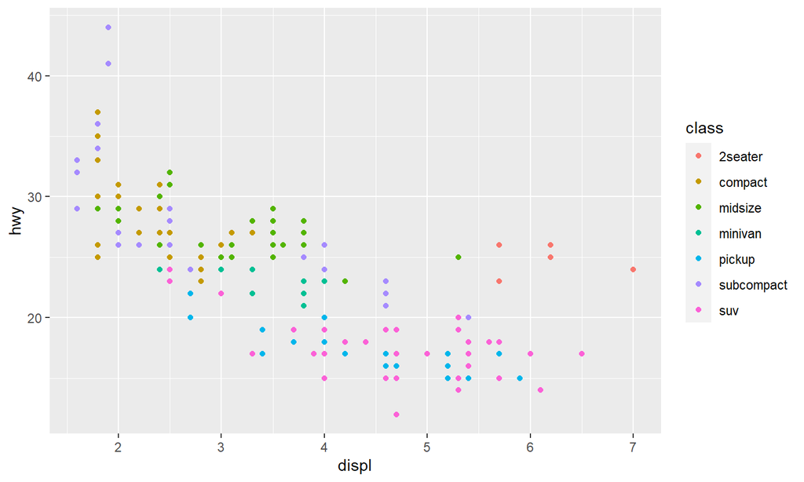

- scales define how the mapping you specify inside `aes()` should happen. All mappings have an associated scale even if not specified - based on the vector type of a class,a discrete colour is picked

## ggplot2 - scales - 2

- we can take control by adding one explicitly
- RColorBrewer::display.brewer.all()

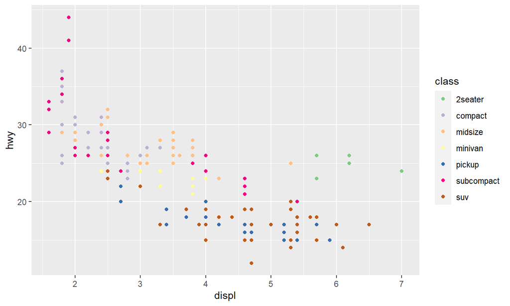

```r
ggplot(mpg) +
  geom_point(aes(x = displ, y = hwy, colour = class)) +
  scale_colour_brewer(type = 'qual')
```

## ggplot2 - scales - 3

- positional mappings (x and y) also have associated scales.

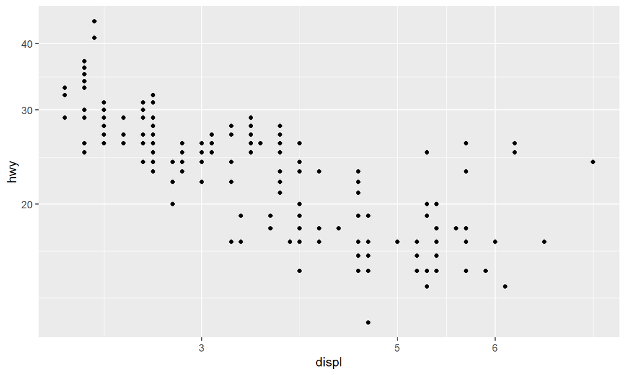

```r
ggplot(mpg) +
  geom_point(aes(x = displ, y = hwy)) +
  scale_x_continuous(breaks = c(3, 5, 6)) +
  scale_y_continuous(trans = 'log10')
```

## Lab

- open ggplot2 and solve the 6-7 excercises

## ggplot2 - facet

- the facet defines how data is split among panels. The default facet (`facet_null()`) puts all the data in a single panel
- `facet_wrap()` and `facet_grid()` allows you to specify different types of small multiples
- mind the scales

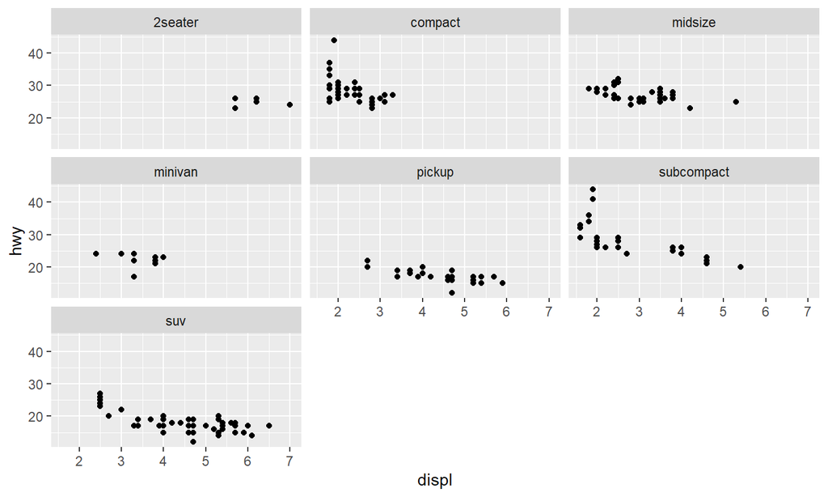

```r
ggplot(mpg) +
  geom_point(aes(x = displ, y = hwy)) +
  facet_wrap(~ class)
```

## Lab

- open ggplot2 and solve the 8-9 excercises
- scales and space can have free_x, free_y and free values

## ggplot2 - coordinates - 1

- the coordinate system is the fabric you draw your layers on in the end
- the default `coord_cartesion provides the standard rectangular x-y coordinate system
- changing the coordinate system can have dramatic effects

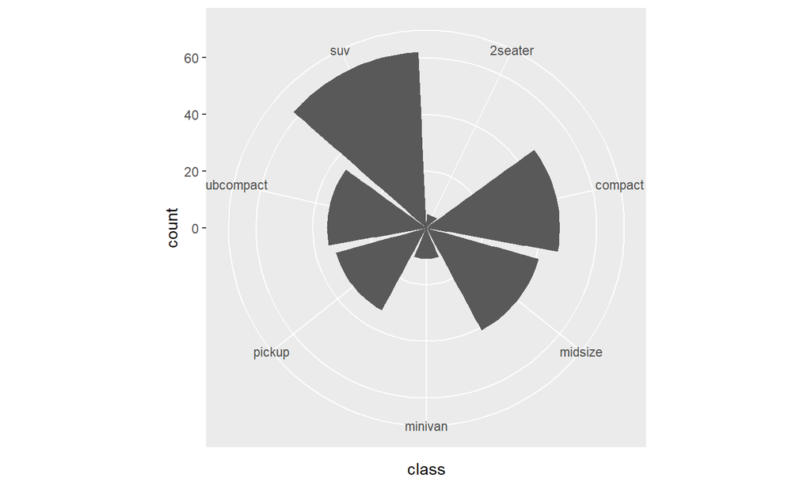

```r
ggplot(mpg) +
  geom_bar(aes(x = class)) +
  coord_polar()
```

## ggplot2 - coordinates - 2

- changing mapping

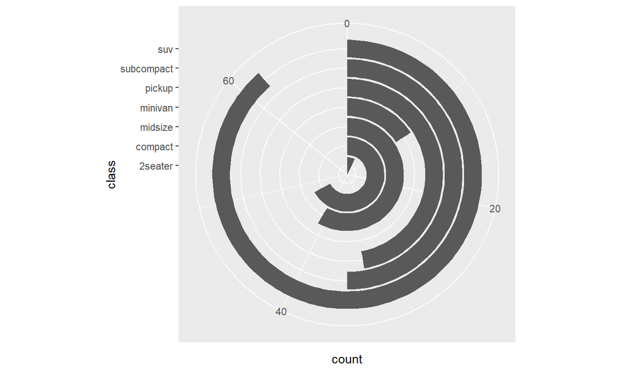

```r
ggplot(mpg) +
  geom_bar(aes(x = class)) +
  coord_polar(theta = 'y') +
  expand_limits(y = 70)
```

## ggplot2 - coordinates - 3

- zooming with scales removes data outside limits

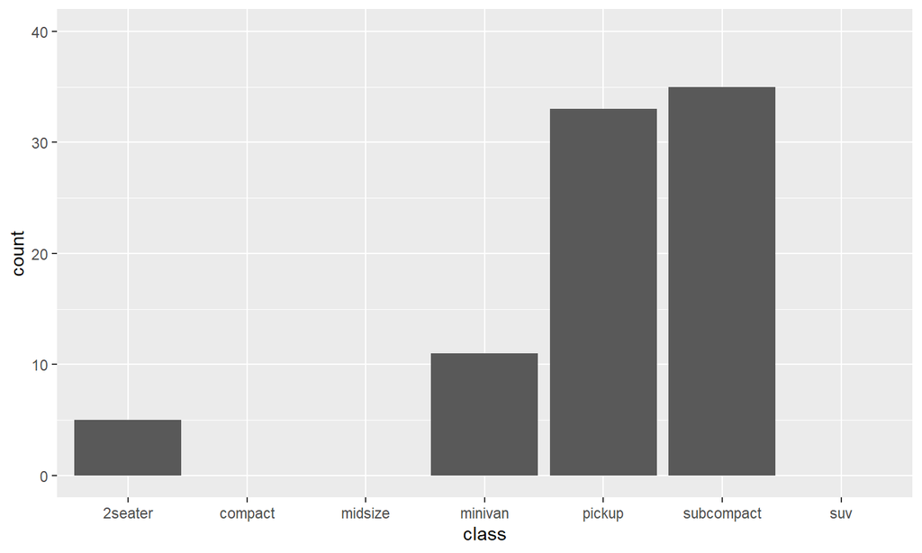

```r
ggplot(mpg) +
  geom_bar(aes(x = class)) +
  scale_y_continuous(limits = c(0, 40))
```

## ggplot2 - coordinates - 4

- zooming with coords creates proper zoom

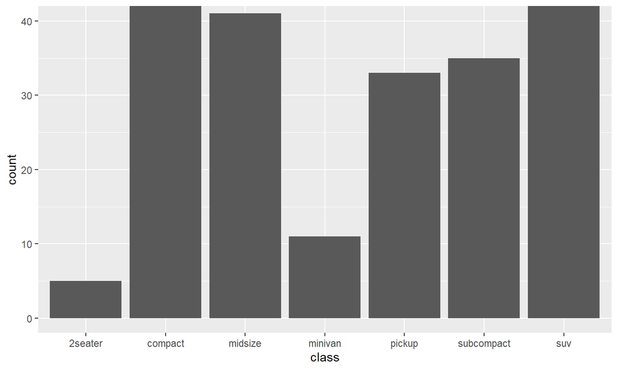

```r
ggplot(mpg) +
  geom_bar(aes(x = class)) +
  coord_cartesian(ylim = c(0, 40))
```

## ggplot2 - coordinates - 5

- scale vs. coordinate transformation

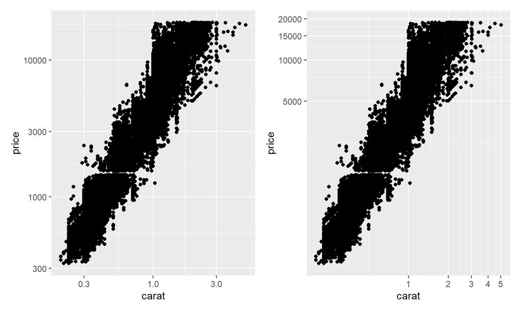

```r
scale<-ggplot(diamonds, aes(carat, price)) +
  geom_point() +
  scale_x_log10() +
  scale_y_log10()
coord<-ggplot(diamonds, aes(carat, price)) +
  geom_point() +
  coord_trans(x = "log10", y = "log10")
(scale | coord)
```

## Lab

- open ggplot2 and solve the 10th excercise

## ggplot2 - themes - 1

- theming defines the feel and look of your final visualisation
- it is very easy to change looks with a prebuild theme
- few themes in ggplot2 package
- for more install ggthemes package

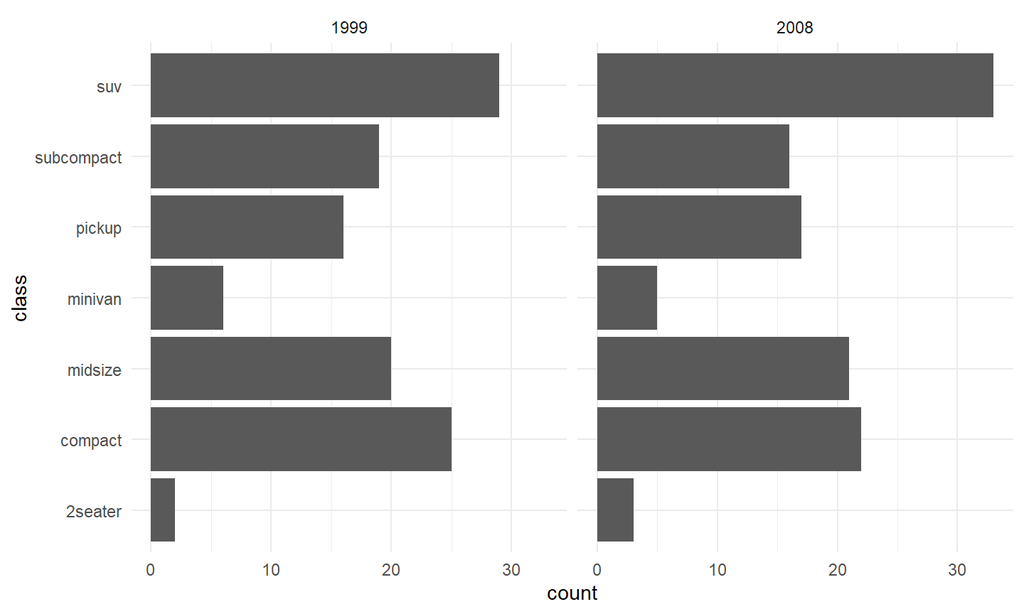

```r
ggplot(mpg) +
  geom_bar(aes(y = class)) +
  facet_wrap(~year) +
  theme_minimal()
```

## ggplot2 - themes - 2

```
ggplot(mpg) +
  geom_bar(aes(y = class)) +
  facet_wrap(~year) +
  labs(title = "Number of car models per class",
       caption = "source: http://fueleconomy.gov",
       x = NULL,
       y = NULL) +
  scale_x_continuous(expand = c(0, NA)) +
  theme_minimal() +
  theme(
    text = element_text('Avenir Next Condensed'),
    strip.text = element_text(face = 'bold', hjust = 0),
    plot.caption = element_text(face = 'italic'),
    panel.grid.major = element_line('white', size = 0.5),
    panel.grid.minor = element_blank(),
    panel.grid.major.y = element_blank(),
    panel.ontop = TRUE
  )
```

## ggplot2 - themes - 3

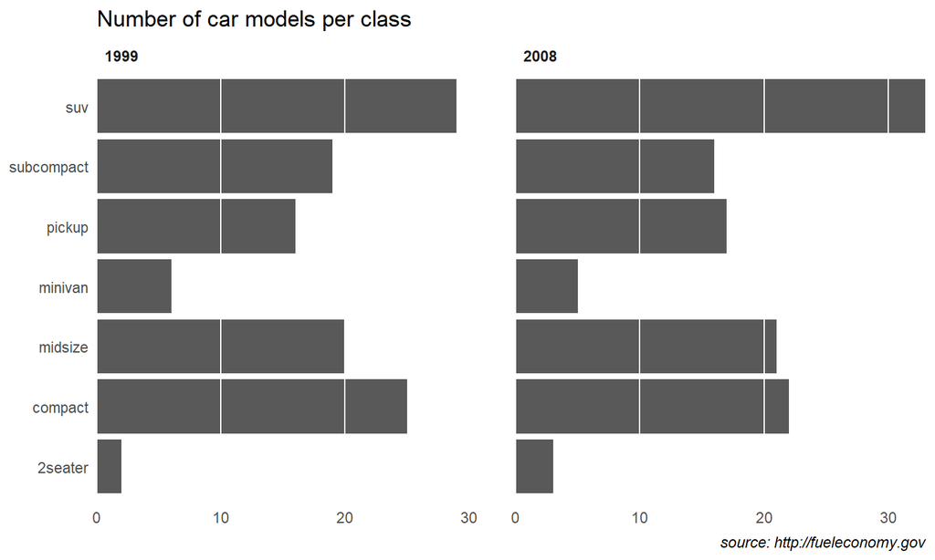

## ggplot2 - extensions

- plot composition:
  - gridExtra::grid.arange()
  - ggpubr::ggarange()
  - patchwork